# Pre-filtering VCF files and Differentiation of Monoclonal and Polyclonal samples

Paulo Manrique

2023-04-27

# 1 Background

# 2 Methods

## 2.1 Section 1: Filtering of VCF files

### 2.1.1 Setp 1: Filter of non core regions, coding regions, and samples of interest.

For this first step we require the following files:

- `.vcf.gz` or `.vcf` files: If a `.vcf.gz` is used, a `.vcf.tbi` will be also required. For this tutorial the `.vfc.gz` file that we are going to work with is: `ColombiaGates_Pviv.JointCall.filtered.combined.snpeff.vcf.gz`.
- `.gff`: the gff file of the reference genome will be also required in order to filter coding regions.
- `noncore_regions.bed`: This file will be used to remove non-core regions that are difficult to sequence from the analysis.
- `load_libraries.R`: This R script file load all the required packages that we need to perform the analysis.
- `functions.R`: This R script file load all the functions that we have created to perform the analysis. Within those functions we a function named `fx_run_vcftools` that allow us to manipulate the `vcftools` package from the R environment. We have also created other functions to get information from the `.vcf` file with loading the whole file in R environment. This functions will help us the get information regarding to the name of the samples and create a `samples.indv` to use as a filter in the analysis. Other functions will be explained later in this tutorial.
- `Filtering_vcf_file.R`: This R script file contains the instructions to perform the analysis in R. This script requires 9 arguments:
  - `wd`: Working directory where all temporal files and final outputs will be stored.
  - `fd`: Directory where the pre-required files are stored.
  - `gzvcf`: Path to the `.vcf.gz` file.
  - `o`: prefix used for the temporal and final outputs.
  - `rkeep`: regular expression to identify samples of interest.
  - `ebed`: name of the `noncore_regions.bed` file. This file should be stored in the `fd` path.
  - `gff`: name of the `.gff` file. This file should be stored in the `fd` path.
  - `n`: number of iterations. In the final step of this script we are going to transform our data from VCF format to rGenome format. This step is computing exhausting and consumes RAM memory. For that reason we subdivide this step in `n` instances to be able to run in the server.
  - `thres`: Minimum read depth to call an allele in a sample.
- `r_options.sh`: bash script with the instructions to run R. This file should be stored in `wd`. The scrip should looks as follow:

```bash
##!/bin/bash
# source /broad/software/scripts/useuse
# use R-4.1
# Rscript /gsap/garage-protistvector/ColombiaData/Pviv/AnalysisTools/Filtering_vcf_file.R \
#   -wd /gsap/garage-protistvector/ColombiaData/Pviv/DataGeneration/post_vcall_analysis/ \
#   -fd /gsap/garage-protistvector/ColombiaData/Pviv/AnalysisTools \
#   -gzvcf /gsap/garage-protistvector/ColombiaData/Pviv/DataGeneration/ColombiaGates_Pviv.JointCall.filtered.combined.snpeff.vcf.gz \
#   -o ColombiaGates \
#   -rkeep (Col|SP) \
#   -ebed Pvivax_P01_noncore.bed \
#   -gff genes.gff \
#   -n 500 \
#   -thres 5
```

- `uger_options.sh`: bash script with the instruction to run UGER. This file should be stored in `wd`. The scrip should looks as follow:

```bash
##!/bin/bash
#qsub -l h_vmem=32G \
#   -l h_rt=01:00:00 \
#   -o /gsap/garage-protistvector/ColombiaData/Pviv/DataGeneration/post_vcall_analysis/output/ \
#   /gsap/garage-protistvector/ColombiaData/Pviv/DataGeneration/post_vcall_analysis/r_options.sh
```

As a final output this step will generate and `.RData` file containing the data in `rGenome` format.

### 2.1.2 Step 2: Filter of potential PCR genotyping artifacts (Missing data, Homopolymers & Short Tandem Repeats)

1. Load the rGenome Object and required libraries and functions:

```r
load('ColombiaGates_1st_2nd_filters.RData')
rm(list = ls()[-grep('rGenome_object|vcf_object',ls())])

rGenome_object@data$metadata = data.frame(sample = names(vcf_object)[-1:-9])

source('load_libraries.R')
source('functions.R')
sourceCpp('Rcpp_functions.cpp')
```

2. Add Metadata.

```r
rGenome_object@data$metadata %<>% mutate(Population = case_when(
    grepl('Colombia_301010', sample) ~ 'Buenaventura_2016',
    grepl('Colombia_301021', sample) ~ 'Tierralta_2016',
    grepl('Colombia_301111', sample) ~ 'Choco_2016',
    grepl('Colombia_301031', sample) ~ 'Tumaco_2016',
    grepl('SP0101254',sample) ~ 'Buenaventura_2020',
    grepl('SP0112286',sample) ~ 'Quibdo_2020',
    grepl('SP0126288',sample) ~ 'Guapi_2020'
  ))
```

#### 2.1.2.1 Step 2.1: Missing data

3. Remove samples with low amplification rate.

3.1 Sample amplification rate

```r
rGenome_object = SampleAmplRate(rGenome_object)
```

3.2 Check the distribution of the amplification rate of the samples using a histogram

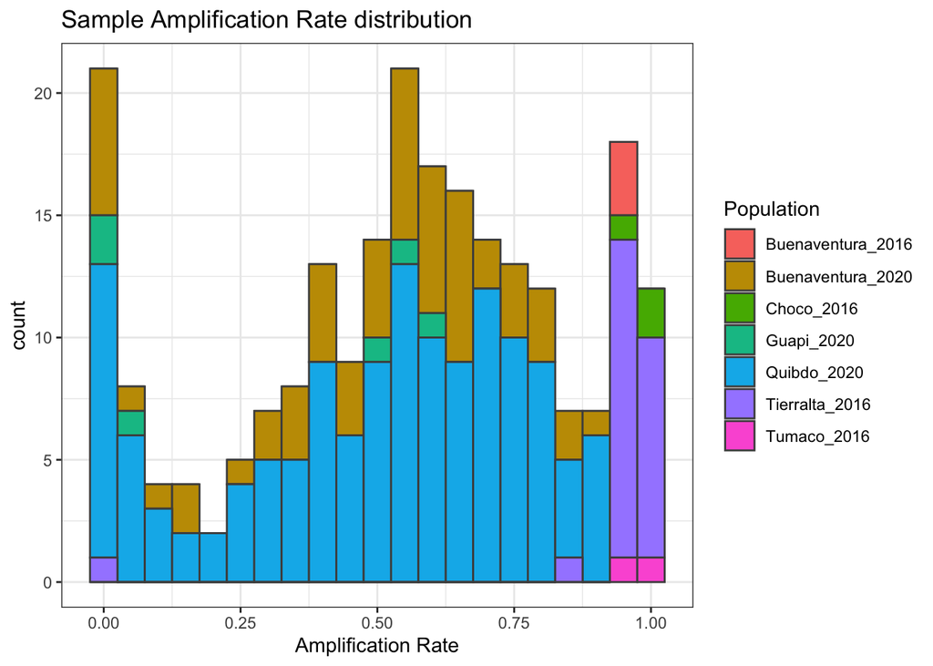

```r
rGenome_object@data$metadata %>% ggplot(aes(x = SampleAmplRate, fill = Population))+
  geom_histogram(position = 'stack', binwidth = .05, color = 'gray30')+
  theme_bw()+
  labs(title = 'Sample Amplification Rate distribution',
       x = 'Amplification Rate')
```

3.3 Remove samples with less than 75% of amplified loci (> 25% of missing data)

```r
rGenome_object = filter_samples(obj = rGenome_object, v =
                rGenome_object@data$metadata$SampleAmplRate >= .75)
```

4. Remove monomorphic sites

4.1 Update allele counts

```r
rGenome_object@data$loci_table = cbind(rGenome_object@data$loci_table,
                                       get_AC(obj = rGenome_object))
rGenome_object = filter_loci(rGenome_object,
                             v = rGenome_object@data$loci_table$Cardinality > 1)
```

5. Remove loci with high missing data

```r
rGenome_object = LocusAmplRate(rGenome_object)
rGenome_object = filter_loci(rGenome_object, v = rGenome_object@data$loci_table$LocusAmplRate >= .75)
```

6. Update alternative alleles

```r
rGenome_object@data$loci_table$ALT =
  ifelse(rGenome_object@data$loci_table$REF !=
           gsub(',([ATCG]|\\*)+',
                '',
                gsub(':\\d+',
                     '',
                     rGenome_object@data$loci_table$Alleles)),
         gsub(':\\d+',
              '',
              rGenome_object@data$loci_table$Alleles),
         gsub('^([ATCG]|\\*)+,',
              '',
              gsub(':\\d+', '', rGenome_object@data$loci_table$Alleles))
       )
```

#### 2.1.2.2 Step 2.2: Homopolymers and Short tandem repeats

7. Differentiate between SNPs, INDELS, Homopolymers and Short tandem repeats

```r
rGenome_object@data$loci_table$TypeOf_Markers =
  TypeOf_Marker(rGenome_object, w = 1, n = 1)
```

##### 2.1.2.2.1 Effect of PCR genotyping artifacts on heterozygosity

8. Get Proportion of Heterozygous samples per site

```r
rGenome_object@data$loci_table$ObsHet = get_ObsHet(rGenome_object, by = 'loci', w = 1, n = 1)
```

9. Calculate fraction of Heterozygous samples per Alternative alleles per site

```r
rGenome_object@data$loci_table$frac_ofHet_pAlts =
  frac_ofHet_pAlt(rGenome_object, w = 1, n = 1)
```

10. Classify sites based on the proportion of alternative alleles in polyclonal samples per site

10.1 Distribution of the fraction of alternative alleles in polyclonal samples

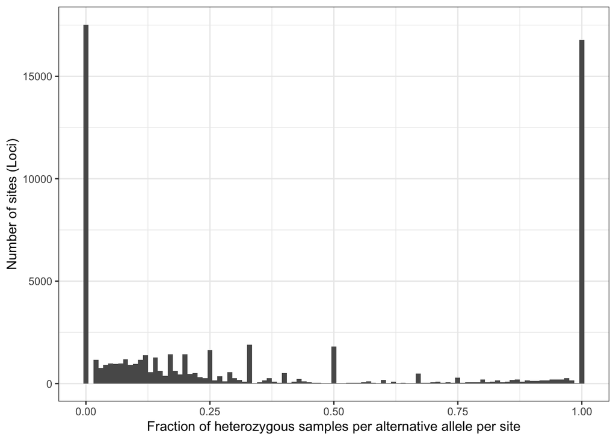

```r
rGenome_object@data$loci_table %>% ggplot(aes(x = frac_ofHet_pAlts))+
    geom_histogram(binwidth = 0.01)+
    labs(x = 'Fraction of heterozygous samples per alternative allele per site',
         y = 'Number of sites (Loci)')+
    theme_bw()
```

10.2 Classify sites based on the proportion of alternative alleles in polyclonal samples per site

```r
rGenome_object@data$loci_table %<>% mutate(ALT_FILTER =case_when(
    frac_ofHet_pAlts == 1 ~ '100%',
    frac_ofHet_pAlts < 1 & frac_ofHet_pAlts > .5 ~ '50 - 99%',
    frac_ofHet_pAlts <= .5 ~ '<=50%',
  ))
```

10.3 Distribution of observed heterozygosity per locus, by type of marker, by group (defined in previuos step 10.2)

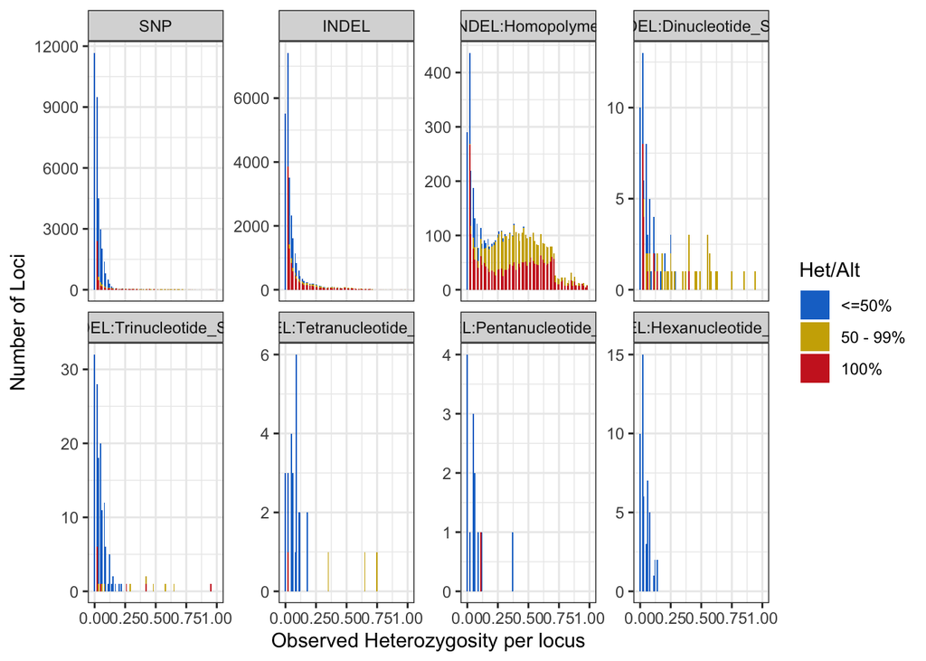

```r
rGenome_object@data$loci_table %>%
    ggplot(aes(x = ObsHet,
               fill = factor(ALT_FILTER,
                             levels = c('<=50%', '50 - 99%', '100%'))))+
    geom_histogram(binwidth = .01)+
    scale_fill_manual(values = c('dodgerblue3', 'gold3', 'firebrick3'))+
    facet_wrap(.~factor(TypeOf_Markers, levels = c(
      'SNP',
      'INDEL',
      'INDEL:Homopolymer',
      'INDEL:Dinucleotide_STR',
      'INDEL:Trinucleotide_STR',
      'INDEL:Tetranucleotide_STR',
      'INDEL:Pentanucleotide_STR',
      'INDEL:Hexanucleotide_STR'
    )), scales = 'free_y', ncol = 4)+
    labs(y = 'Number of Loci',
         x = 'Observed Heterozygosity per locus',
         fill = 'Het/Alt')+
    theme_bw()
```

11. Remove Homopolymers and DiSTRs

```r
rGenome_object = filter_loci(rGenome_object,
            v = !(rGenome_object@data$loci_table$TypeOf_Markers %in%
                    c('INDEL:Homopolymer', 'INDEL:Dinucleotide_STR')))
```

### 2.1.3 Step 3: Filter of problematic genomic regions to map reads

#### 2.1.3.1 Regions with excess of Heterozygosity

12. Distribution of proportion of heterozygous per site by sites with <= 50% Het/Alt, 50 - 99% Het/Alt and 100% of Het/Alt

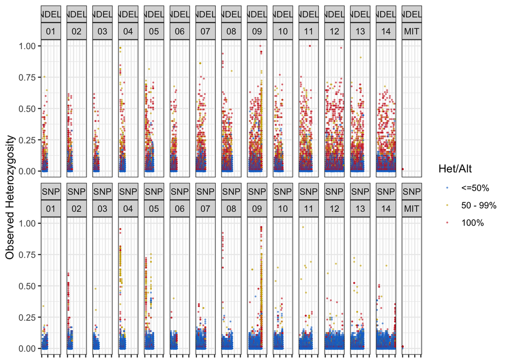

```r
  # In that way we identify that maximum fraction of Heterozygous samples per loci is 0.4855491

rGenome_object@data$loci_table %>%
    mutate(TypeOf_Markers2 = case_when(
      TypeOf_Markers == 'SNP' ~ 'SNP',
      TypeOf_Markers != 'SNP' ~ 'INDELs'),
      CHROM2  = gsub('(^(\\d|P|v)+_|_v1)', '',CHROM))%>%
    ggplot(aes(x = POS, y = ObsHet, color = factor(ALT_FILTER, levels = c('<=50%', '50 - 99%', '100%')))) +
    geom_point(alpha = 0.5, size = .25) +
    scale_color_manual(values = c('dodgerblue3', 'gold3', 'firebrick3'))+
    facet_wrap(TypeOf_Markers2 ~ CHROM2, ncol = 15)+
    theme_bw()+
    labs(y = 'Observed Heterozygosity', x = 'Chromosomal position', color = 'Het/Alt')+
    theme(legend.position = 'right',
          axis.text.x = element_blank(),
          axis.title.x = element_blank())
```

13. Calculate the average of heterozygous samples per site per gene

```r
rGenome_object@data$loci_table = mean_ObsHet(rGenome_object, gff = 'genes.gff')
```

14. Define a threshold for trusted variants

```r
ObsHet_Threshold = quantile(rGenome_object@data$loci_table %>%
                                filter(ALT_FILTER == '<=50%', TypeOf_Markers == 'SNP') %>%
                                group_by(gene_id) %>%
                                dplyr::summarise(mean_ObsHet = max(mean_ObsHet)) %>%
                                select(mean_ObsHet) %>%
                                unlist, .99)
```

15. Visualize the Average Observed Heteozygosity in SNPs per genomic position

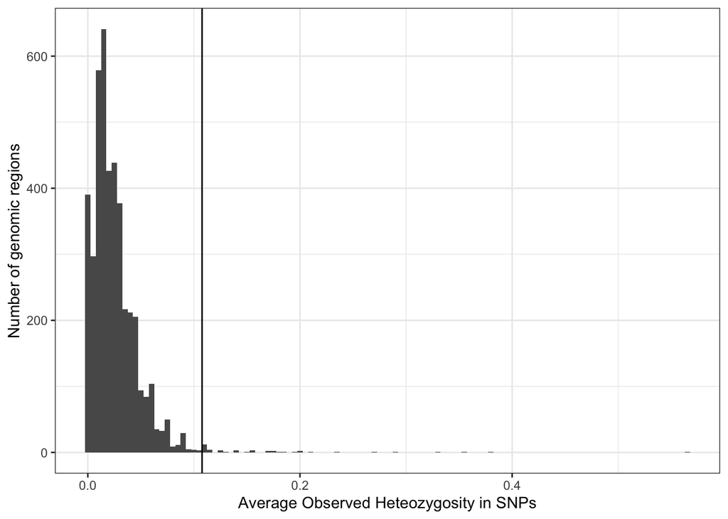

```r
rGenome_object@data$loci_table %>%
    filter(ALT_FILTER == '<=50%', TypeOf_Markers == 'SNP') %>%
    group_by(gene_id) %>%
    dplyr::summarise(mean_ObsHet = max(mean_ObsHet)) %>%
    ggplot(aes(x = mean_ObsHet))+
    geom_histogram(binwidth = .005)+
    geom_vline(xintercept = ObsHet_Threshold)+
    labs(y = 'Number of genomic regions', x = 'Average Observed Heteozygosity in SNPs') +
    theme_bw()
```

16. Differentiate genomic regions that PASS the threshold

```r
rGenome_object@data$loci_table %<>% mutate(ObsHet_Filter = case_when(
    mean_ObsHet > ObsHet_Threshold ~ 'OUT',
    mean_ObsHet <= ObsHet_Threshold ~ 'PASS'
  ))
```

17. Visualize which genomic regons PASS the filter

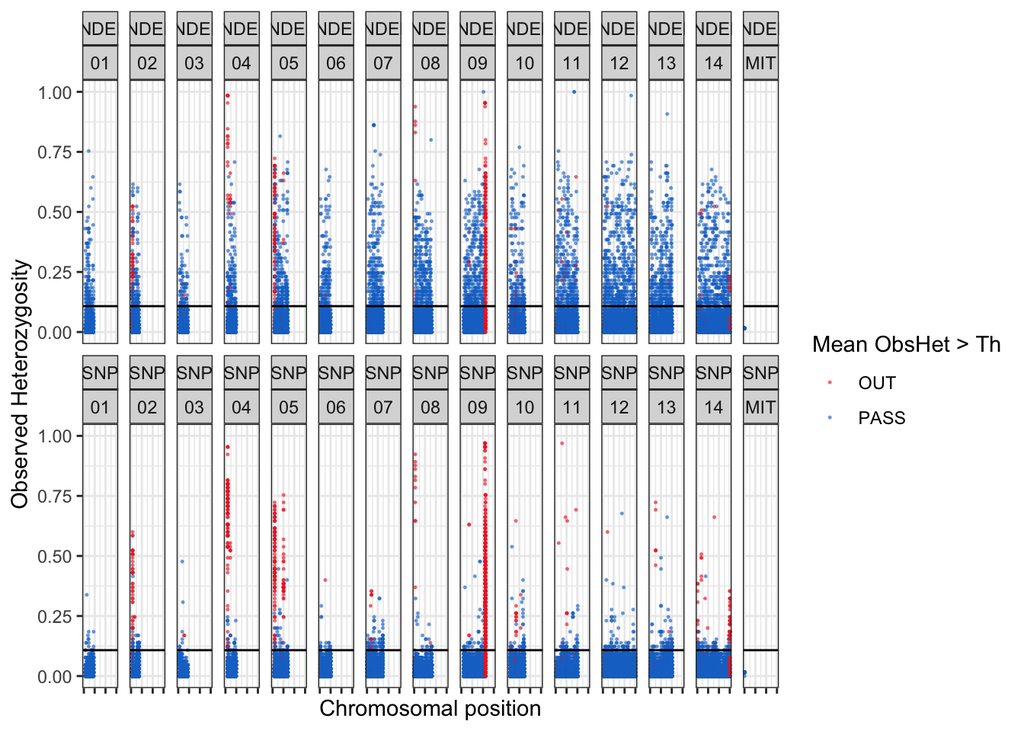

```r
rGenome_object@data$loci_table %>%
    mutate(TypeOf_Markers2 = case_when(
      TypeOf_Markers == 'SNP' ~ 'SNP',
      TypeOf_Markers != 'SNP' ~ 'INDEL'),
      CHROM2  = gsub('(^(\\d|P|v)+_|_v1)', '',CHROM))%>%
    ggplot(aes(x = POS, y = ObsHet, color = ObsHet_Filter)) +
    geom_point(alpha = 0.5, size = .25) +
    geom_hline(yintercept = ObsHet_Threshold)+
    scale_color_manual(values = c('firebrick2', 'dodgerblue3'))+
    facet_wrap(TypeOf_Markers2 ~ CHROM2, ncol = 15)+
    theme_bw()+
    labs(y = 'Observed Heterozygosity',
         x = 'Chromosomal position',
         color = 'Mean ObsHet > Th')+
    theme(legend.position = 'right',
          axis.text.x = element_blank())
```

#### 2.1.3.2 Regions with excess of density of Polymorphism

18. Calculate the density of SNPs per genomic region and define a threshold

```r
rGenome_object@data$loci_table = SNP_density(rGenome_object, gff = 'genes.gff')

SNP_density_threshold = quantile(rGenome_object@data$loci_table %>%
                                     filter(TypeOf_Markers == 'SNP') %>%
                                     group_by(gene_id) %>%
                                     dplyr::summarise(SNP_density = max(SNP_density)) %>%
                                     select(SNP_density) %>%
                                     unlist, .99)
```

19. Distribution of SNP density

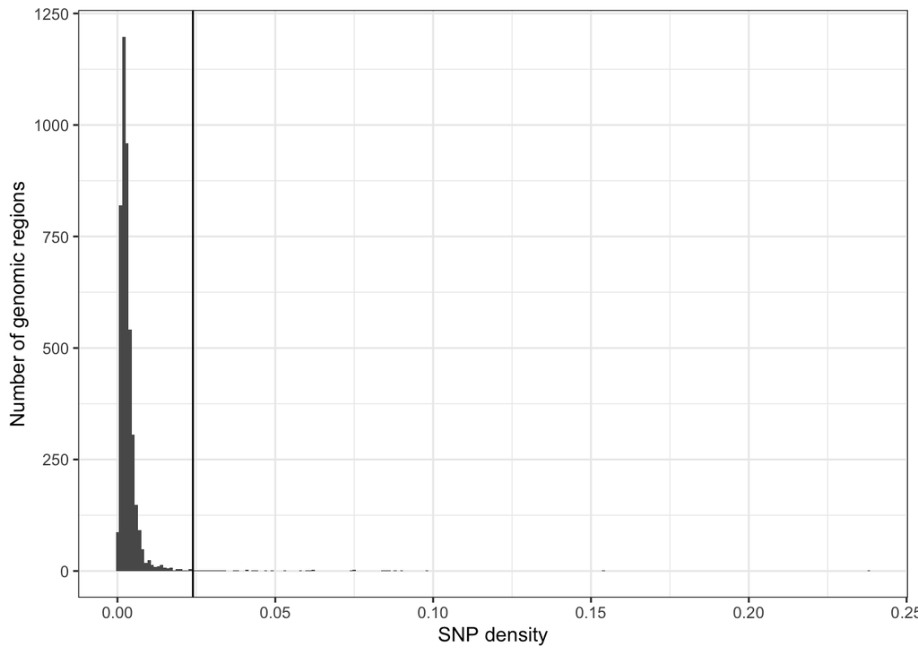

```r
rGenome_object@data$loci_table %>%
    filter(TypeOf_Markers == 'SNP') %>%
    group_by(gene_id) %>%
    dplyr::summarise(SNP_density = max(SNP_density)) %>%
    ggplot(aes(x = SNP_density))+
    geom_histogram(binwidth = .001)+
    geom_vline(xintercept = SNP_density_threshold)+
    labs(y = 'Number of genomic regions', x = 'SNP density') +
    theme_bw()
```

20. Differentiate/Filter genomic regions that PASS the threshold

```r
rGenome_object@data$loci_table %<>%
  mutate(SNP_density_Filter = case_when(
    SNP_density > SNP_density_threshold ~ 'OUT',
    SNP_density <= SNP_density_threshold ~ 'PASS'
  ))
```

21. Visualize which genomic regons PASS the filter

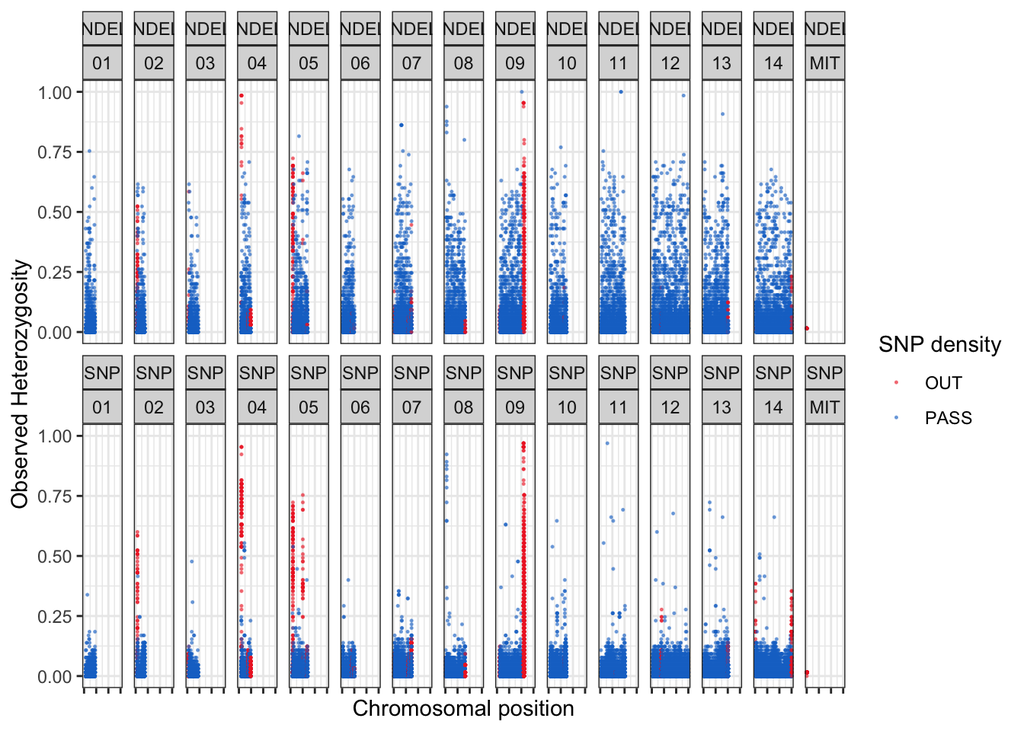

```r
rGenome_object@data$loci_table %>%
    mutate(TypeOf_Markers2 = case_when(
      TypeOf_Markers == 'SNP' ~ 'SNP',
      TypeOf_Markers != 'SNP' ~ 'INDEL'),
      CHROM2  = gsub('(^(\\d|P|v)+_|_v1)', '',CHROM))%>%
    ggplot(aes(x = POS, y = ObsHet, color = SNP_density_Filter)) +
    geom_point(alpha = 0.5, size = .25) +
    scale_color_manual(values = c('firebrick2', 'dodgerblue3'))+
    facet_wrap(TypeOf_Markers2 ~ CHROM2, ncol = 15)+
    theme_bw()+
    labs(y = 'Observed Heterozygosity', x = 'Chromosomal position', color = 'SNP density')+
    theme(legend.position = 'right',
          axis.text.x = element_blank())
```

22. Differentiate of problematic genomic regions to map reads

```r
rGenome_object@data$loci_table %<>%
  mutate(Alignment_Filter = case_when(
    ObsHet_Filter == 'OUT' & SNP_density_Filter == 'OUT' ~ 'OUT',
    !(ObsHet_Filter == 'OUT' & SNP_density_Filter == 'OUT') ~ 'PASS'
  ))
```

23. Visualize which genomic regons PASS the filter

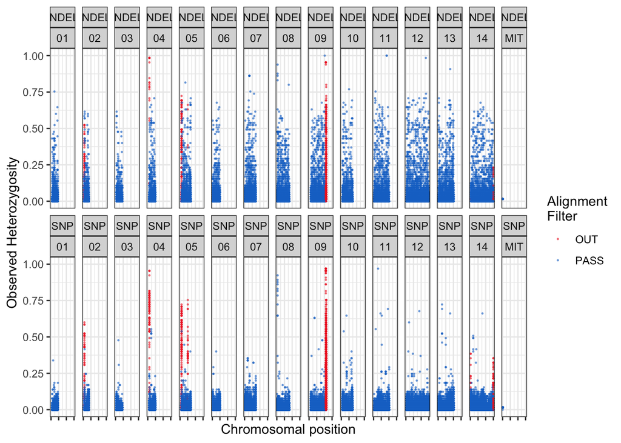

```r
rGenome_object@data$loci_table %>%
    mutate(TypeOf_Markers2 = case_when(
      TypeOf_Markers == 'SNP' ~ 'SNP',
      TypeOf_Markers != 'SNP' ~ 'INDEL'),
      CHROM2  = gsub('(^(\\d|P|v)+_|_v1)', '',CHROM))%>%
    ggplot(aes(x = POS, y = ObsHet, color = Alignment_Filter)) +
    geom_point(alpha = 0.5, size = .25) +
    scale_color_manual(values = c('firebrick2', 'dodgerblue3'))+
    facet_wrap(TypeOf_Markers2 ~ CHROM2, ncol = 15)+
    theme_bw()+
    labs(y = 'Observed Heterozygosity', x = 'Chromosomal position', color = 'Alignment\nFilter')+
    theme(legend.position = 'right',
          axis.text.x = element_blank())
```

24. Check which genomic regions or genes are removed

```r
rGenome_object@data$loci_table %>%
  filter(Alignment_Filter == 'OUT') %>%
  select(gene_id) %>%
  unique()
```

```
##                           gene_id
## PvP01_02_v1_146279  PVP01_0202900
## PvP01_04_v1_212026  PVP01_0404700
## PvP01_05_v1_194673  PVP01_0504500
## PvP01_05_v1_1010827 PVP01_0524900
## PvP01_09_v1_2186941 PVP01_0949400
## PvP01_09_v1_2201069 PVP01_0949600
## PvP01_09_v1_2221421 PVP01_0950000
## PvP01_09_v1_2233000 PVP01_0950200
## PvP01_14_v1_34628   PVP01_1400900
## PvP01_14_v1_3009456 PVP01_1470400
```

25. Remove problematic genomic regions to map reads

```r
rGenome_object =
  filter_loci(rGenome_object,
              v = rGenome_object@data$loci_table$Alignment_Filter == 'PASS')
```

# 3 Section 2: Differentiating monoclonal and polyclonal infections

26. Define the fraction of heterozygous loci per sample

```r
rGenome_object@data$metadata$fracHet =
  get_ObsHet(obj = rGenome_object, by = 'sample')
```

27. Within host divergence (Fws) per sample

```r
rGenome_object@data$metadata$Fws =
  get_Fws(obj = rGenome_object, w = 1, n = 1)
```

28. Visualize distribution of Heterozygosity and Fws

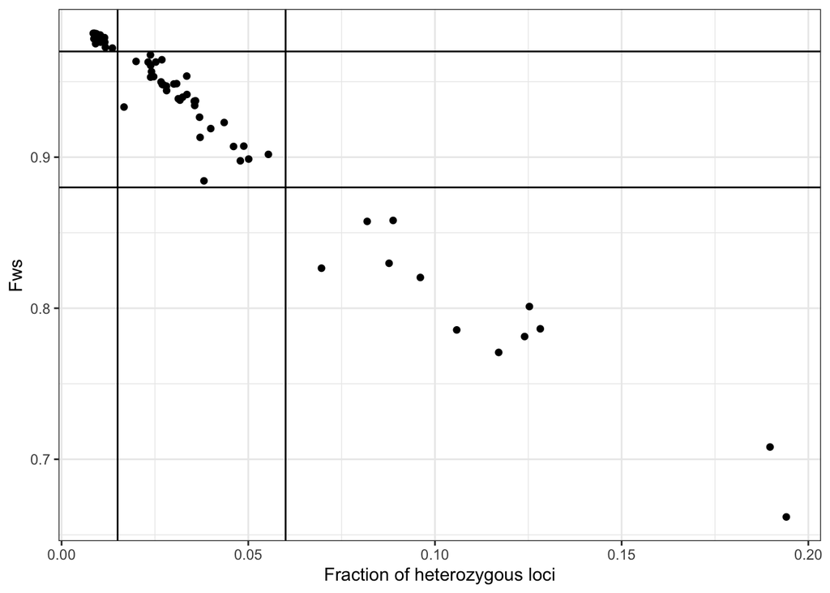

```r
rGenome_object@data$metadata %>%
  ggplot(aes(x = fracHet, y = Fws))+
    geom_point()+
    geom_hline(yintercept = .97)+
    geom_hline(yintercept = .88)+
    geom_vline(xintercept = .015)+
    geom_vline(xintercept = .06)+
    labs(x = 'Fraction of heterozygous loci')+
    theme_bw()
```

29. Defining Monoclonal, Highly related polyclonal, and Polyclonal infections

```r
rGenome_object@data$metadata %<>%
  mutate(Clonality = case_when(
    Fws >= .97 & fracHet <= .015 ~ 'Monoclonal',
    Fws < .97 & fracHet > .015 & Fws >= .88 & fracHet <= .06 ~ 'Highly related Polyclonal',
    Fws < .88 & fracHet > .06 ~ 'Polyclonal'
  ))
```

30. Save data

```r
rm(list = ls()[-grep('rGenome_object',ls())])
save.image('ColombiaGates_filtered_rGenome.RData')
```